# Forecasting Project

Mary Anna Kivenson

March 21, 2020

# Part A

I want you to forecast how much cash is taken out of 4 different ATM machines for May 2010. The data is given in a single file. The variable ‘Cash’ is provided in hundreds of dollars, other than that it is straight forward. I am being somewhat ambiguous on purpose to make this have a little more business feeling. Explain and demonstrate your process, techniques used and not used, and your actual forecast. I am giving you data via an excel file, please provide your written report on your findings, visuals, discussion and your R code via an RPubs link along with the actual.rmd file Also please submit the forecast which you will put in an Excel readable file.

## Data Exploration

### Summary

Let’s begin by taking a look at a summary of each of the ATM withdrawal time series. One important item to note is that each of the time series has missing values. There is also a very high withdrawal in the ATM4 time series that should be addressed.

```r
summary(df)
```

```
##       DATE                          ATM1             ATM2
##  Min.   :2009-05-01 00:00:00   Min.   :  1.00   Min.   :  0.00
##  1st Qu.:2009-08-03 12:00:00   1st Qu.: 73.00   1st Qu.: 25.50
##  Median :2009-11-06 00:00:00   Median : 91.00   Median : 67.00
##  Mean   :2009-11-06 00:00:00   Mean   : 83.89   Mean   : 62.58
##  3rd Qu.:2010-02-08 12:00:00   3rd Qu.:108.00   3rd Qu.: 93.00
##  Max.   :2010-05-14 00:00:00   Max.   :180.00   Max.   :147.00
##                                NA's   :17       NA's   :16
##       ATM3              ATM4
##  Min.   : 0.0000   Min.   :    1.563
##  1st Qu.: 0.0000   1st Qu.:  124.334
##  Median : 0.0000   Median :  403.839
##  Mean   : 0.7206   Mean   :  474.043
##  3rd Qu.: 0.0000   3rd Qu.:  704.507
##  Max.   :96.0000   Max.   :10919.762
##  NA's   :14        NA's   :14
```

### Visualization

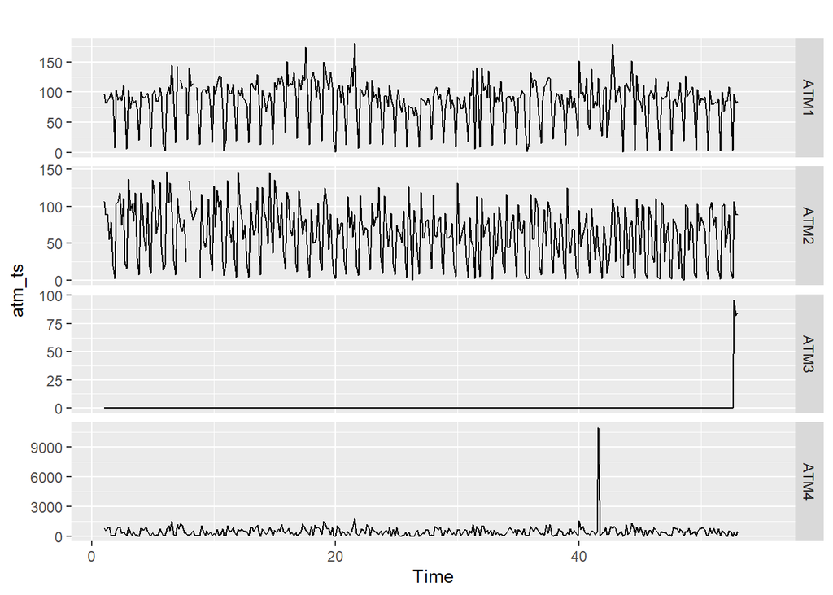

```r
atm_ts <- ts(df %>% select(ATM1:ATM4), frequency=7)
autoplot(atm_ts, facet = TRUE)
```

### Missing Data

Taking a look at the time series, there is no data avilable from 5/1/2010 - 5/14/2010 for any of the ATMs - this time period will be removed from our dataset. There are also a few missing values in the ATM 1 and ATM 2 time series in June 2009. These missing values will be replaced using the `tsclean()` function. The `tsclean` function will also replaces any outliers in the data, so it will address the outlier in the ATM4 dataset (along with any other outliers).

```r
df[rowSums(is.na(df)) > 0,]
```

```
## # A tibble: 19 x 5
##    DATE                 ATM1  ATM2  ATM3  ATM4
##    <dttm>              <dbl> <dbl> <dbl> <dbl>
##  1 2009-06-13 00:00:00    NA    91     0 746.
##  2 2009-06-16 00:00:00    NA    82     0 373.
##  3 2009-06-18 00:00:00    21    NA     0  92.5
##  4 2009-06-22 00:00:00    NA    90     0  80.6
##  5 2009-06-24 00:00:00    66    NA     0  90.6
##  6 2010-05-01 00:00:00    NA    NA    NA  NA
##  7 2010-05-02 00:00:00    NA    NA    NA  NA
##  8 2010-05-03 00:00:00    NA    NA    NA  NA
##  9 2010-05-04 00:00:00    NA    NA    NA  NA
## 10 2010-05-05 00:00:00    NA    NA    NA  NA
## 11 2010-05-06 00:00:00    NA    NA    NA  NA
## 12 2010-05-07 00:00:00    NA    NA    NA  NA
## 13 2010-05-08 00:00:00    NA    NA    NA  NA
## 14 2010-05-09 00:00:00    NA    NA    NA  NA
## 15 2010-05-10 00:00:00    NA    NA    NA  NA
## 16 2010-05-11 00:00:00    NA    NA    NA  NA
## 17 2010-05-12 00:00:00    NA    NA    NA  NA
## 18 2010-05-13 00:00:00    NA    NA    NA  NA
## 19 2010-05-14 00:00:00    NA    NA    NA  NA
```

#### Test train split

```r
atm1_train <- subset(atm_ts[,1], end = length(atm_ts[,1])- 80)
atm1_test <- subset(atm_ts[,1], start = length(atm_ts[,1]) - 79, end = length(atm_ts[,1]) - 14)

atm2_train <- subset(atm_ts[,2], end = length(atm_ts[,2])- 80)
atm2_test <- subset(atm_ts[,2], start = length(atm_ts[,2]) - 79, end = length(atm_ts[,2]) - 14)

atm3_train <- subset(atm_ts[,3], end = length(atm_ts[,3])- 80)
atm3_test <- subset(atm_ts[,3], start = length(atm_ts[,3]) - 79, end = length(atm_ts[,3]) - 14)

atm4_train <- subset(atm_ts[,4], end = length(atm_ts[,4])- 80)
atm4_test <- subset(atm_ts[,4], start = length(atm_ts[,4]) - 79, end = length(atm_ts[,4] - 14))
```

```r
atm1_train <- tsclean(atm1_train)
atm2_train <- tsclean(atm2_train)
atm4_train <- tsclean(atm4_train)
```

### Models

Now that the outliers and missing values in the dataset have been addressed, we will split the data into train-test sets and apply the following models:

- Seasonally Adjusted Decomposition
- Holt-Winters Seasonal Exponential Smoothing
- Seasonal ARIMA

#### Decomposition

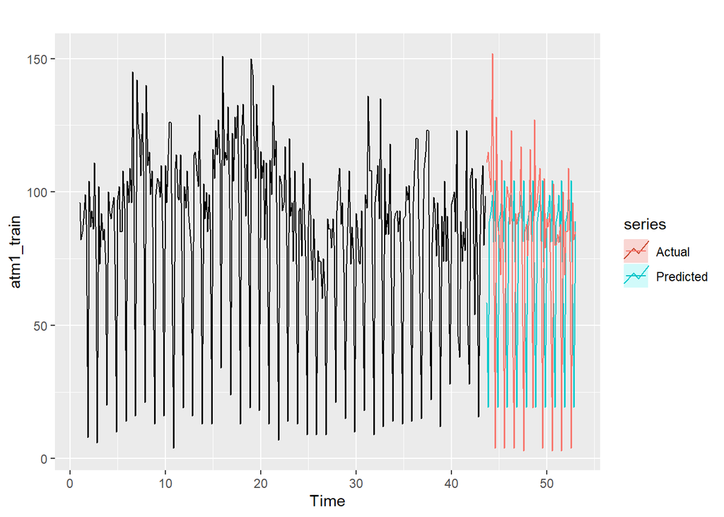

```r
fit <- stlf(atm1_train, h = 66)
atm1_forecast_decomp <- forecast(fit, method="naive", h = 66)
autoplot(atm1_train) +
autolayer(atm1_forecast_decomp, PI = FALSE, series = 'Predicted') +
  autolayer(atm1_test, series = 'Actual')
```

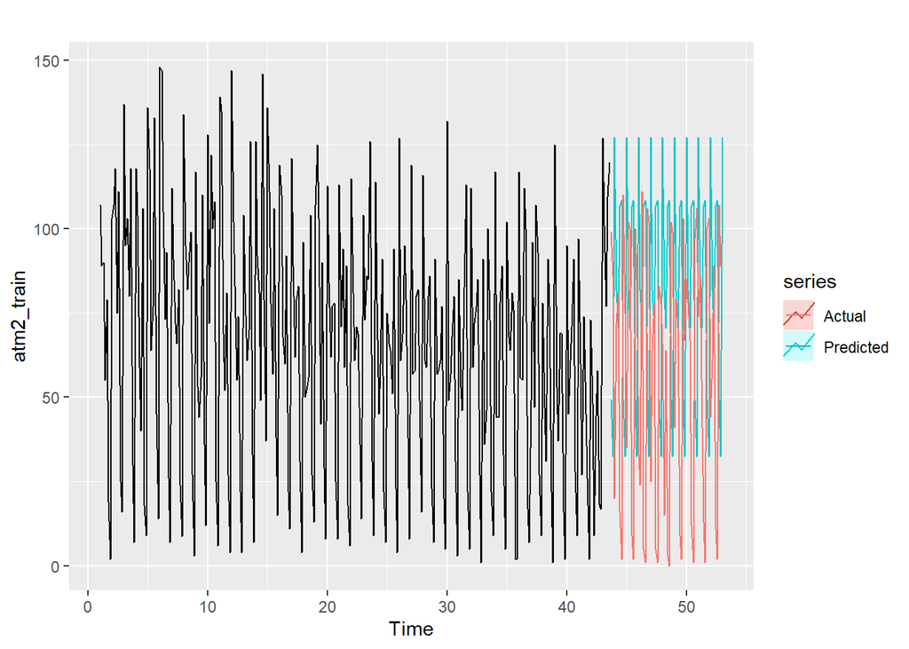

```r
fit <- stlf(atm2_train, robust=TRUE, h = 66)
atm2_forecast_decomp <- forecast(fit, method="naive", h = 66)
autoplot(atm2_train) +
autolayer(atm2_forecast_decomp, PI = FALSE, series = 'Predicted') +
  autolayer(atm2_test, series = 'Actual')
```

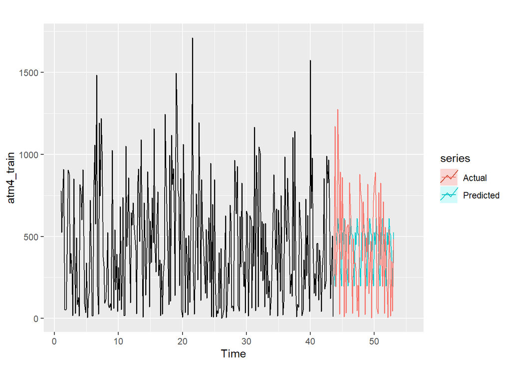

```r
fit <- stlf(atm4_train, robust=TRUE, h = 66)
atm4_forecast_decomp <- forecast(fit, method="naive", h = 66)
autoplot(atm4_train) +
autolayer(atm4_forecast_decomp, PI = FALSE, series = 'Predicted') +
  autolayer(atm4_test, series = 'Actual')
```

#### Exponential Smoothing

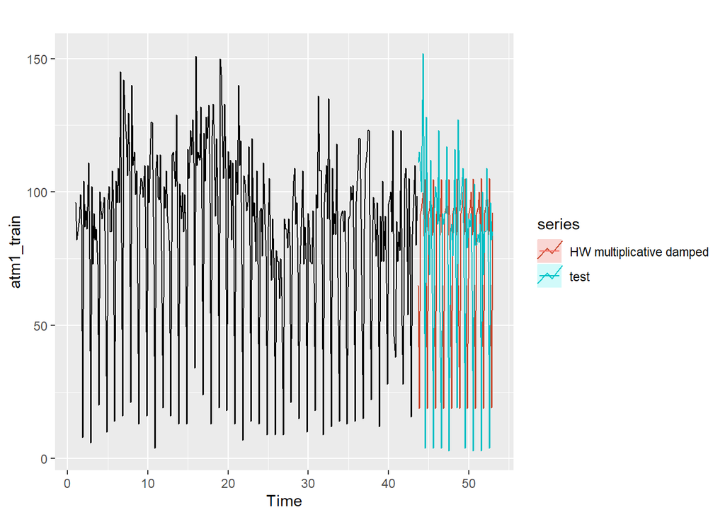

```r
atm1_forecast_es <- hw(atm1_train, damped = TRUE, seasonal="multiplicative", h=66)
autoplot(atm1_train) +
  autolayer(atm1_forecast_es, series="HW multiplicative damped", PI=FALSE) +
  autolayer(atm1_test, series="test")
```

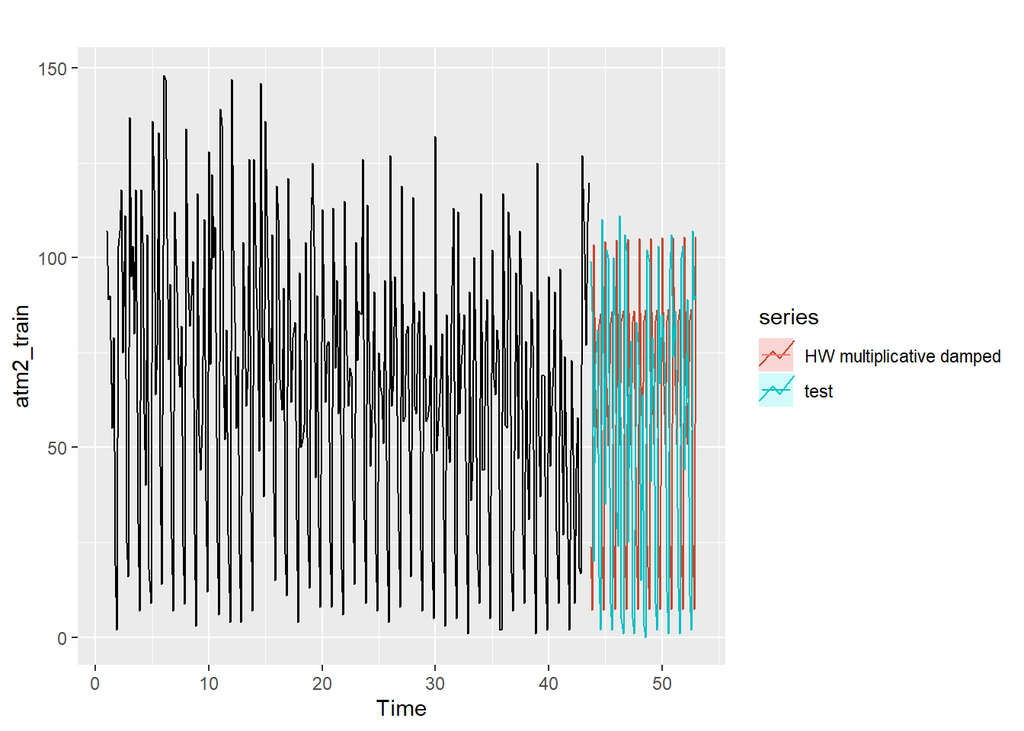

```r
atm2_forecast_es <- hw(atm2_train, damped = TRUE, seasonal="multiplicative", h=66)
autoplot(atm2_train) +
  autolayer(atm2_forecast_es, series="HW multiplicative damped", PI=FALSE) +
  autolayer(atm2_test, series="test")
```

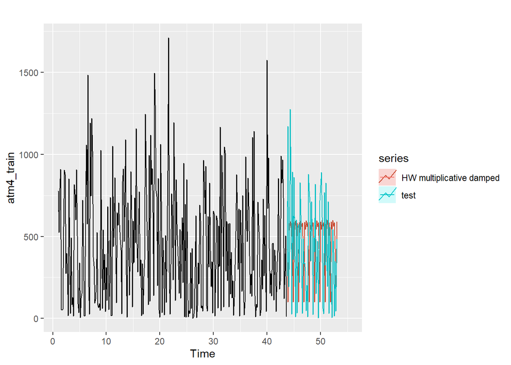

```r
atm4_forecast_es <- hw(atm4_train, damped = TRUE, seasonal="multiplicative", h=66)
autoplot(atm4_train) +
  autolayer(atm4_forecast_es, series="HW multiplicative damped", PI=FALSE) +
  autolayer(atm4_test, series="test")
```

#### ARIMA

```r
atm1_train %>% diff() %>% ur.kpss() %>% summary()
```

```
##
## #######################
## # KPSS Unit Root Test #
## #######################
##
## Test is of type: mu with 5 lags.
##
## Value of test-statistic is: 0.0117
##
## Critical value for a significance level of:
##                 10pct  5pct 2.5pct  1pct
## critical values 0.347 0.463  0.574 0.739
```

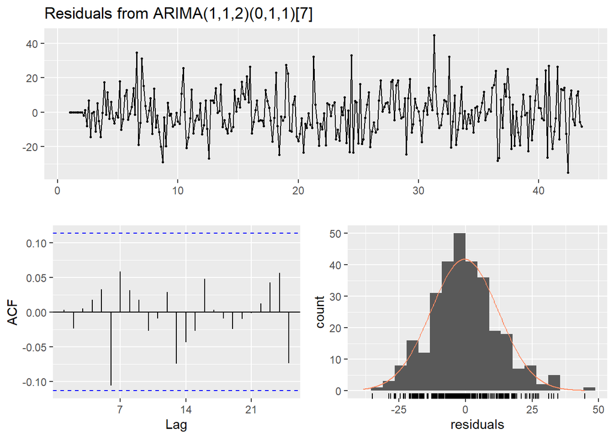

```
##
##  Ljung-Box test
##
## data:  Residuals from ARIMA(1,1,2)(0,1,1)[7]
## Q* = 8.3852, df = 10, p-value = 0.5913
##
## Model df: 4.   Total lags used: 14
```

```r
fit <- Arima(atm1_train, order=c(1,1,2), seasonal=c(0,1,1))
atm1_forecast_arima <- forecast(fit, h = 66)
checkresiduals(fit)
```

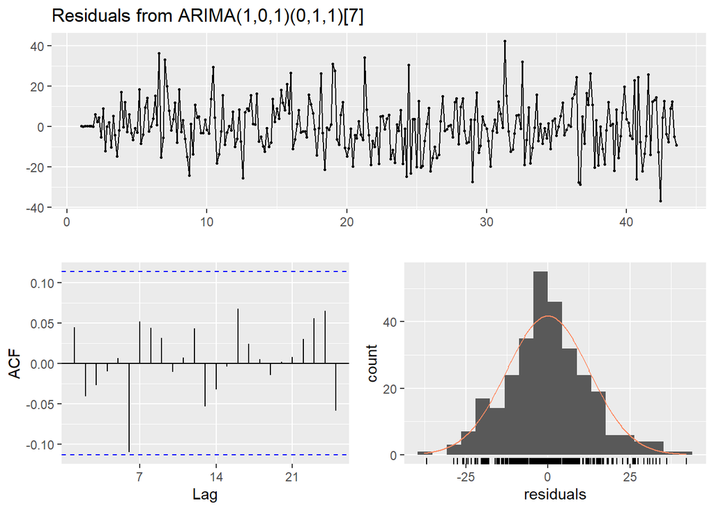

```
##
##  Ljung-Box test
##
## data:  Residuals from ARIMA(1,0,1)(0,1,1)[7]
## Q* = 8.7188, df = 11, p-value = 0.6478
##
## Model df: 3.   Total lags used: 14
```

```r
fit <- auto.arima(atm1_train, seasonal = TRUE)
atm1_forecast_arima <- forecast(fit, h = 66)
checkresiduals(fit)
```

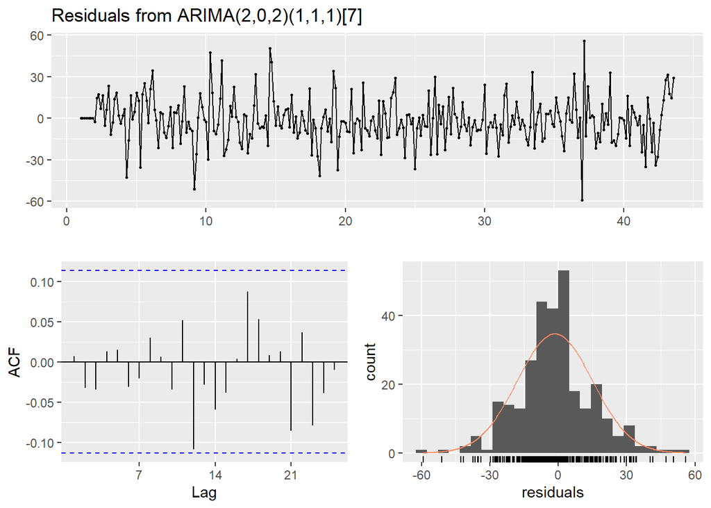

```
##
##  Ljung-Box test
##
## data:  Residuals from ARIMA(2,0,2)(1,1,1)[7]
## Q* = 7.8328, df = 8, p-value = 0.45
##
## Model df: 6.   Total lags used: 14
```

```r
fit <- auto.arima(atm2_train, seasonal = TRUE)
atm2_forecast_arima <- forecast(fit, h = 66)
checkresiduals(fit)
```

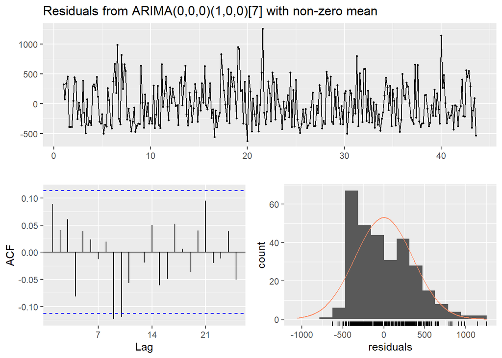

```
##
##  Ljung-Box test
##
## data:  Residuals from ARIMA(0,0,0)(1,0,0)[7] with non-zero mean
## Q* = 17.93, df = 12, p-value = 0.1178
##
## Model df: 2.   Total lags used: 14
```

```r
fit <- auto.arima(atm4_train, seasonal = TRUE)
atm4_forecast_arima <- forecast(fit, h = 66)
checkresiduals(fit)
```

## Model Selection

```r
accuracy(atm1_forecast_decomp, atm1_test)
```

```
##                      ME     RMSE       MAE         MPE      MAPE      MASE
## Training set 0.03987906 11.12631  8.696973   -2.539579  15.11726 0.6790306
## Test set     3.97967740 50.56624 37.454867 -333.716875 376.08736 2.9243510
##                     ACF1 Theil's U
## Training set 0.106121640        NA
## Test set     0.005423657 0.4457812
```

```r
accuracy(atm1_forecast_es, atm1_test)
```

```
##                     ME     RMSE       MAE        MPE      MAPE      MASE
## Training set -1.135609 12.66786  9.604811   -5.58069  15.24724 0.7499116
## Test set      1.807302 49.99224 36.859238 -337.86169 377.52353 2.8778463
##                    ACF1 Theil's U
## Training set 0.21949810        NA
## Test set     0.01888205 0.3800653
```

```r
accuracy(atm1_forecast_arima, atm1_test)
```

```
##                       ME     RMSE       MAE         MPE      MAPE      MASE
## Training set 0.008678903 12.57120  9.520212   -1.574382  16.18471 0.7433064
## Test set     2.129311857 50.41781 37.242056 -340.085643 380.41567 2.9077354
##                     ACF1 Theil's U
## Training set 0.044786723        NA
## Test set     0.006969453 0.4064448
```

```r
accuracy(atm2_forecast_decomp, atm2_test)
```

```
##                       ME     RMSE      MAE      MPE     MAPE      MASE
## Training set   0.2268314 15.93534 11.75782 -12.0918 37.14855 0.6735516
## Test set     -24.1435875 70.16986 60.82856     -Inf      Inf 3.4845895
##                     ACF1 Theil's U
## Training set  0.09997121        NA
## Test set     -0.02520761         0
```

```r
accuracy(atm2_forecast_es, atm2_test)
```

```
##                     ME     RMSE      MAE       MPE     MAPE      MASE
## Training set -1.392066 17.52184 13.29228 -26.09073 40.99487 0.7614538
## Test set     -2.055870 66.56025 60.52233      -Inf      Inf 3.4670471
##                     ACF1 Theil's U
## Training set  0.27213060        NA
## Test set     -0.01308327         0
```

```r
accuracy(atm2_forecast_arima, atm2_test)
```

```
##                     ME     RMSE      MAE       MPE     MAPE      MASE
## Training set -1.513724 16.57676 12.29121 -17.01777 33.80904 0.7041074
## Test set      1.445091 64.25694 58.84157      -Inf      Inf 3.3707639
##                      ACF1 Theil's U
## Training set  0.007268602        NA
## Test set     -0.024761375         0
```

```r
accuracy(atm4_forecast_decomp, atm4_test)
```

```
##                       ME     RMSE      MAE       MPE     MAPE      MASE
## Training set -0.01271048 316.9532 242.4679 -405.9624 436.9329 0.6916603
## Test set     -9.62387245 357.5066 296.9393 -850.5201 890.7776 0.8470445
##                    ACF1 Theil's U
## Training set 0.12879438        NA
## Test set     0.02026442  0.361001
```

```r
accuracy(atm4_forecast_es, atm4_test)
```

```
##                     ME     RMSE      MAE       MPE      MAPE      MASE
## Training set -16.03983 327.2325 256.4662 -447.9828  475.8236 0.7315915
## Test set     -47.83028 380.8470 315.9636 -969.0699 1007.7802 0.9013131
##                    ACF1 Theil's U
## Training set 0.13149556        NA
## Test set     0.04235637 0.2463315
```

```r
accuracy(atm4_forecast_arima, atm4_test)
```

```
##                        ME     RMSE      MAE       MPE    MAPE      MASE
## Training set   0.09624668 352.8342 295.7634 -512.0241 545.606 0.8436902
## Test set     -17.82392662 307.8120 256.8821 -751.0370 780.548 0.7327780
##                     ACF1 Theil's U
## Training set  0.08851479        NA
## Test set     -0.04390885 0.2527174
```

# Part B

Part B consists of a simple dataset of residential power usage for January 1998 until December 2013. Your assignment is to model these data and a monthly forecast for 2014. The data is given in a single file. The variable ‘KWH’ is power consumption in Kilowatt hours, the rest is straight forward. Add this to your existing files above.

## Data Exploration

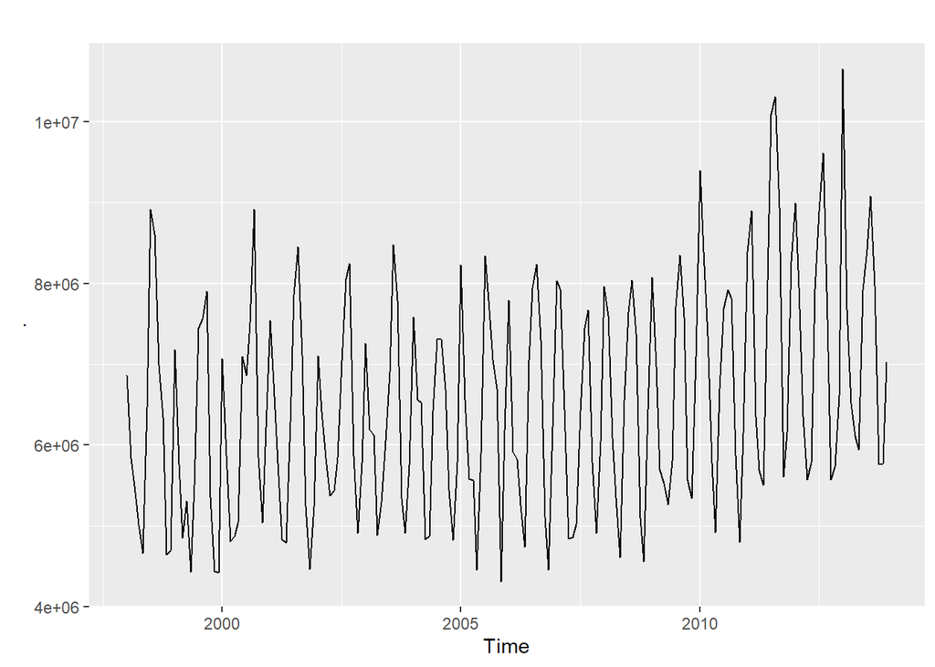

```r
kwh <- ts(df$KWH, frequency = 12, start = c(1998, 1))
kwh %>% tsclean() %>% autoplot()
```

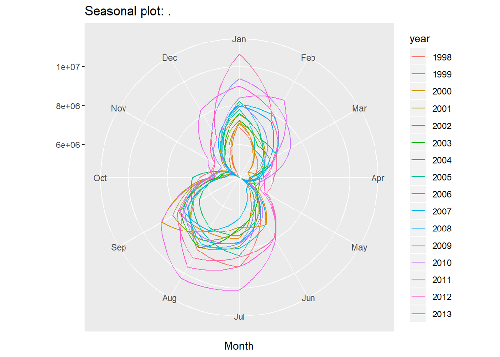

```r
kwh %>% tsclean() %>% ggseasonplot(polar = TRUE)
```

## Model Selection

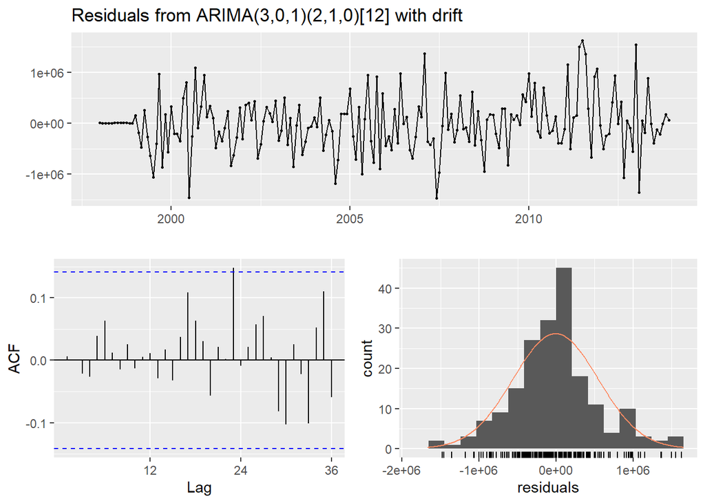

```
##
##  Ljung-Box test
##
## data:  Residuals from ARIMA(3,0,1)(2,1,0)[12] with drift
## Q* = 11.549, df = 17, p-value = 0.8266
##
## Model df: 7.   Total lags used: 24
```

```r
fit <- auto.arima(kwh %>% tsclean(), seasonal = TRUE)
kwh_FIT <- forecast(fit, h = 66)
checkresiduals(kwh_FIT)
```

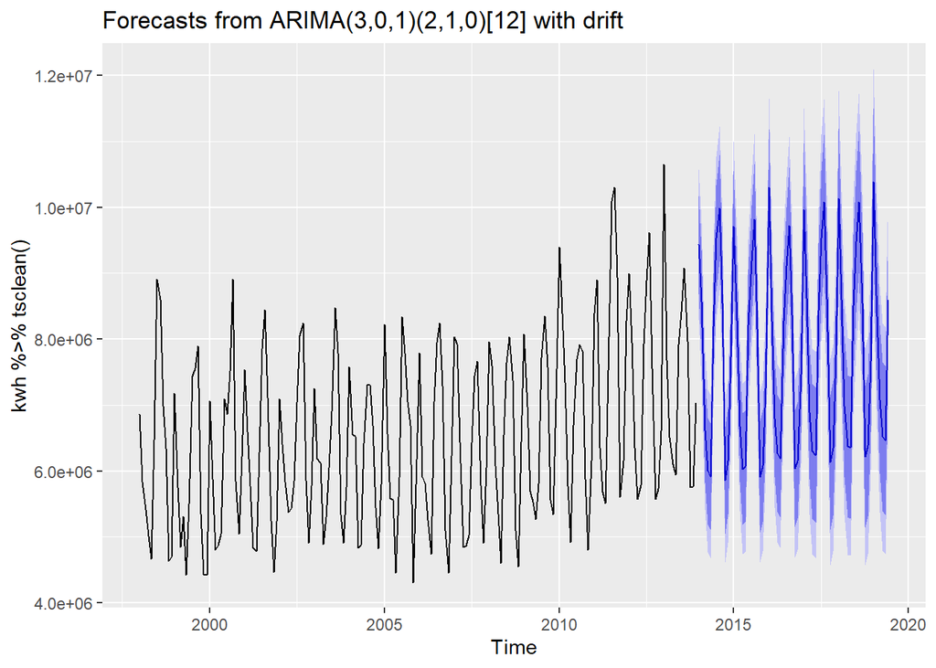

```r
autoplot(kwh_FIT)
```

# Part C

Part C consists of two data sets. These are simple 2 columns sets, however they have different time stamps. Your optional assignment is to time-base sequence the data and aggregate based on hour (example of what this looks like, follows). Note for multiple recordings within an hour, take the mean. Then to determine if the data is stationary and can it be forecast. If so, provide a week forward forecast and present results via Rpubs and .rmd and the forecast in an Excel readable file.